# Презентация по индивидуальнной проекте

Основы информационной безопасности

Нджову Н.

Российский университет дружбы народов, Москва, Россия

27 февралья 2025

## Цель работы

Приобретение практических навыков по установке операционной системы Linux на витуальную машину.

## Задание

1. Установить Kali Linux на витуальную машину.

## Выполнение лабораторной работы

Я создала новую виртуальную машину, указивая имя и образ ISO(рис.1)

[figure not shown]

создание виртуальной машины

## Выполнение лабораторной работы

Я указывала размер основной памяти виртуальной машины и выбрала количество процессора(рис.2)

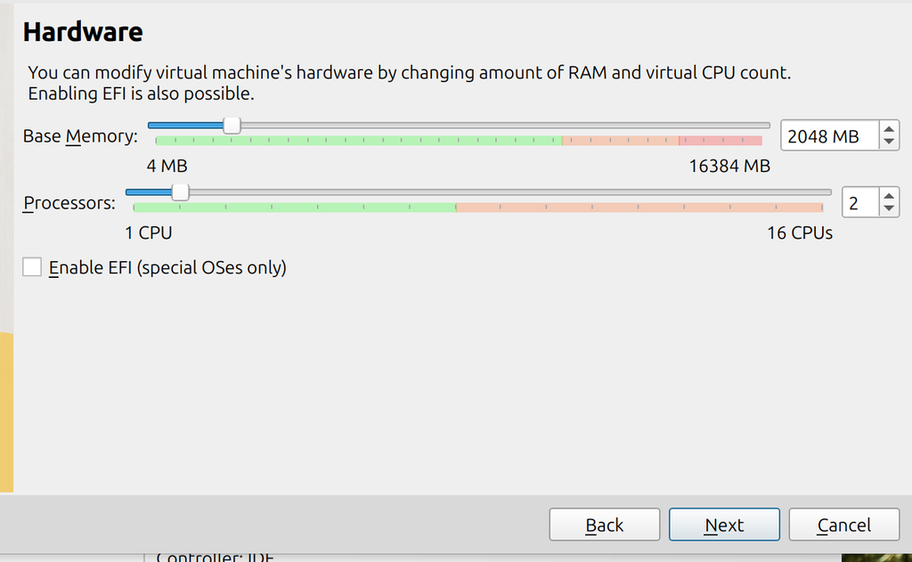

указание размера основной памяти виртуальной машины

## Выполнение лабораторной работы

Я установила размер диска на 40ГБ(рис.3)

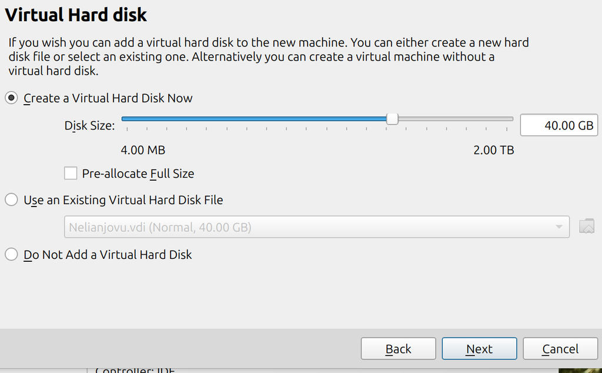

Окно определения размера виртуального динамического жёсткого диска и его расположения

## Выполнение лабораторной работы

Я согласилася с полученными характеристиками(рис.4)

[figure not shown]

создание виртуальной машины

## Выполнение лабораторной работы

Я проверяла подключен ли образ диска к носителю(рис.5)

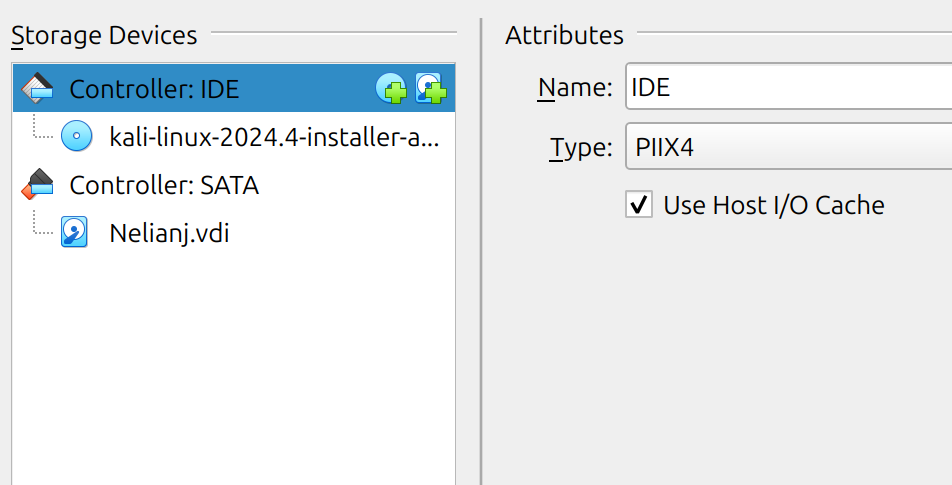

создание виртуальной машины

## Выполнение лабораторной работы

Я запускала виртуальную машину(рис.6)

[figure not shown]

запуск виртуальную машину

## Выполнение лабораторной работы

Я выбрала English в качестве языка интерфейс(рис.7)

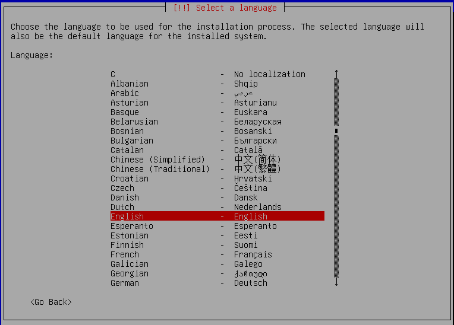

выбор языка

## Выполнение лабораторной работы

Я выбрала место(рис.8)

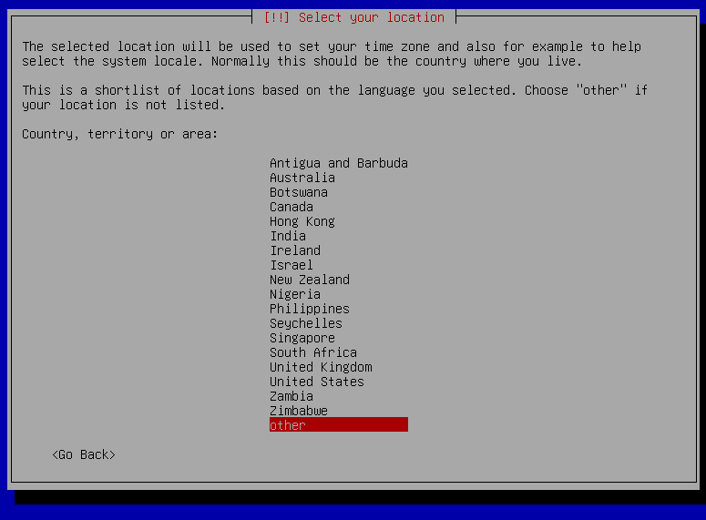

выбор места

## Выполнение лабораторной работы

Я выбрала языки раскладки клавиатуры(рис.9)

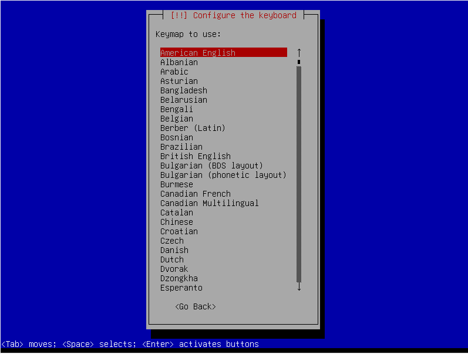

языки раскладки клавиатуры

## Выполнение лабораторной работы

Я ввела имя компьютера(рис.10)

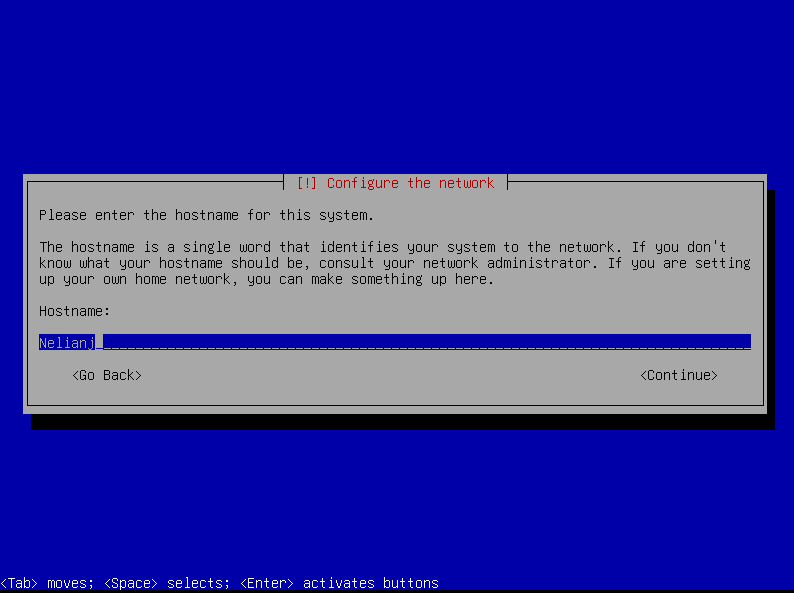

Ввод имени компьютера

## Выполнение лабораторной работы

Я ввела имя домена(рис.11)

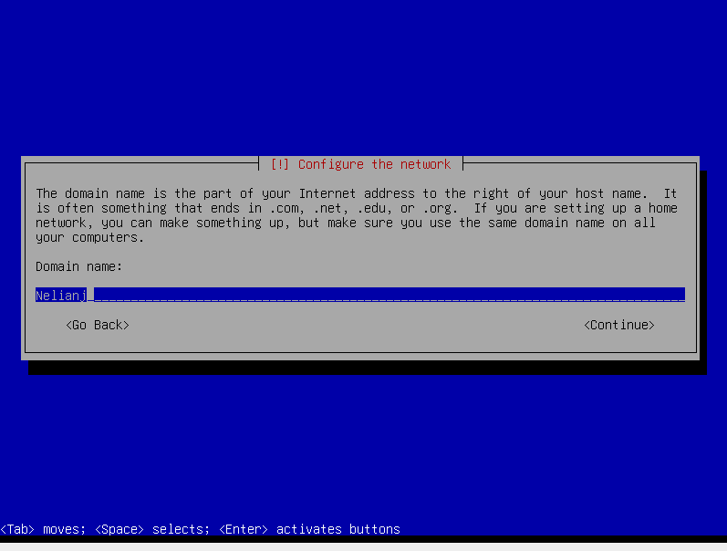

Ввод имени домена

## Выполнение лабораторной работы

Я ввела имя пользователя(рис.12)

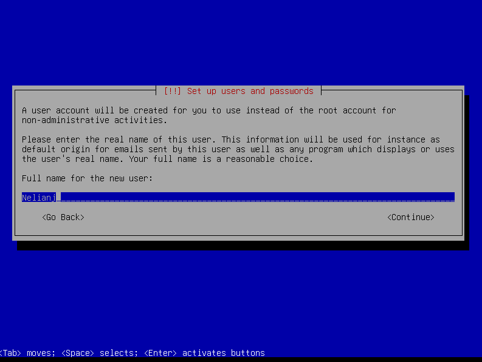

Ввод имени пользователя

## Выполнение лабораторной работы

По умолчанию, это же имя предлагается как имя моей учетной записи-с маленькими буквами(рис.13)

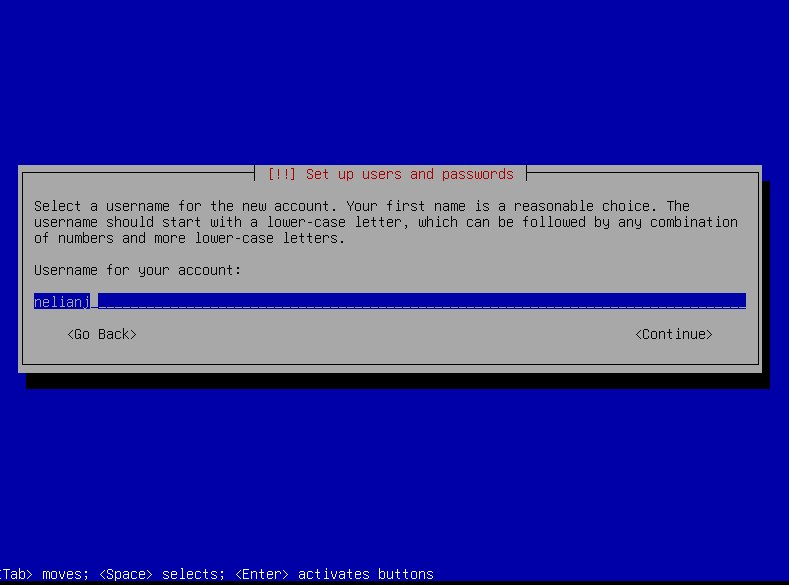

Ввод имени моей учетной записи

## Выполнение лабораторной работы

Я ввела пароль для созданного пользователя(рис.14)

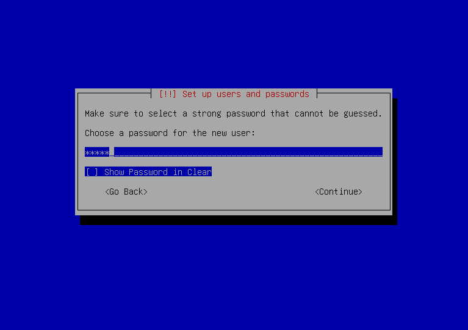

создание пароля

## Выполнение лабораторной работы

Я выбирала часовой пояс(рис.15)

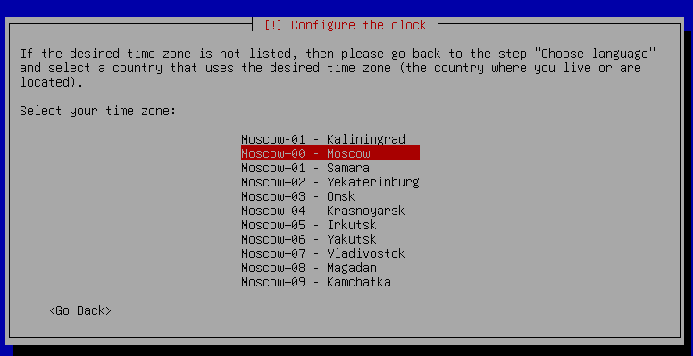

часовой пояс

## Выполнение лабораторной работы

Установщик проверяла диски и предлагала различные варианты, в зависимости от настроек. Созданный виртуальный диск чистый, поэтому я выбирала весь диск(entire disk)(рис.16)

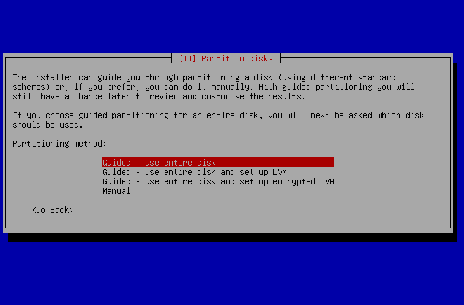

Разметка дисков

## Выполнение лабораторной работы

Затем я выбирала нужный виртуальный диск(рис.17)

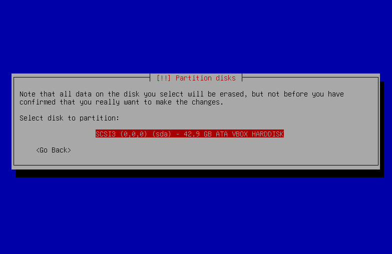

Разметка дисков

## Выполнение лабораторной работы

Далее установщик предлагала выбрать схему разметки, ее я оставляла по умолчанию все файлы в одном разделе(all files in one partition)(рис.18)

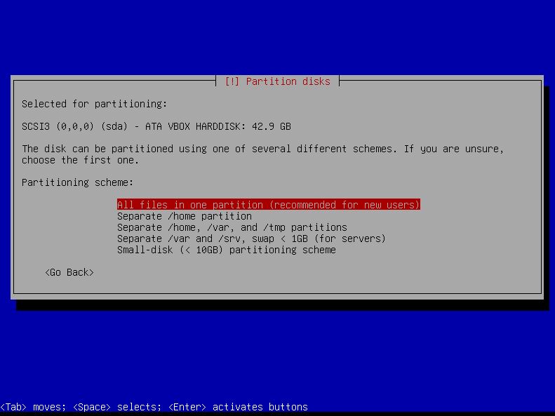

Разметка дисков

## Выполнение лабораторной работы

После этого я подтвердила окончание разбиения диска, чтобы изменения были записаны(рис.19)

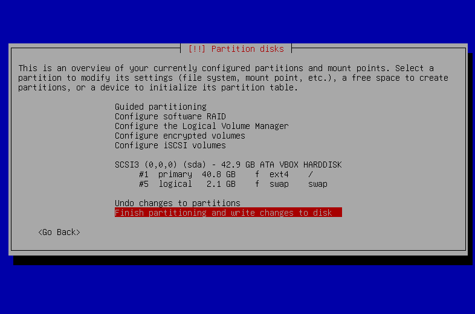

окончание разметка дисков

## Выполнение лабораторной работы

Затем установщик позволяет вам еще раз просмотреть конфигурацию диска, прежде чем вносить постоянные изменения. После этого этапа начнется установка(рис.20)

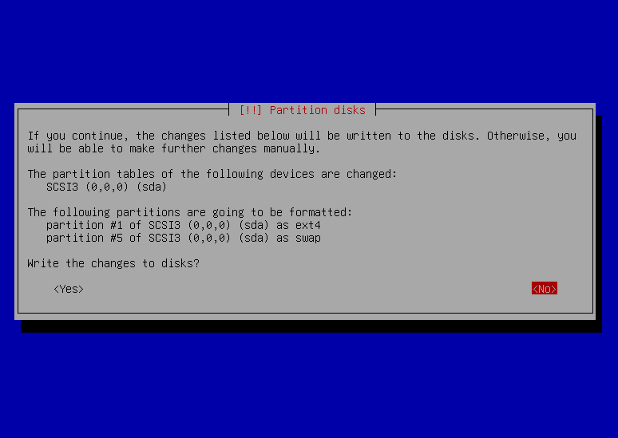

окончание разметка дисков

## Выполнение лабораторной работы

После этого этапа начнется установка(рис.21)

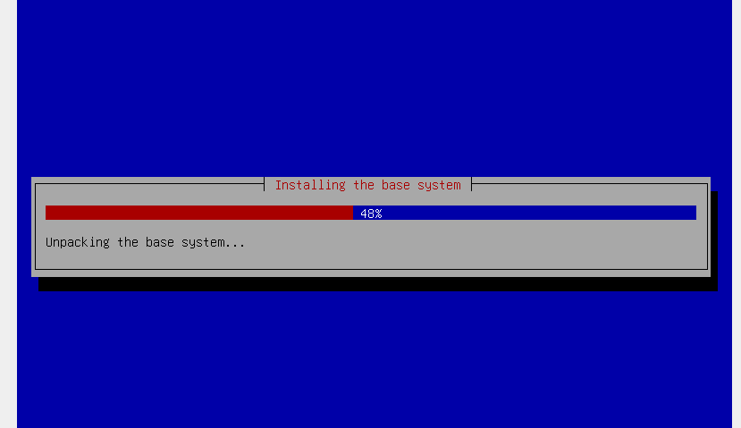

установка

## Выполнение лабораторной работы

Дальше я выбрала какой метапакеты (пустые пакеты, описывающие только зависимости), которые я хотела установить(рис.22)

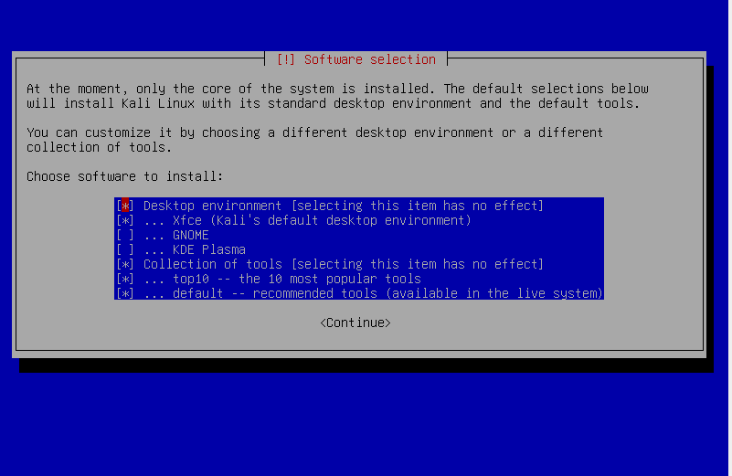

Выбор программного обеспечения

## Выполнение лабораторной работы

Я подтвердила установку системы загрузчика системы GRUB из проекта GNU (программа для управления процессом загрузки),я также выбирала виртуальный диск, на который будет установлен GRUB(рис.23)

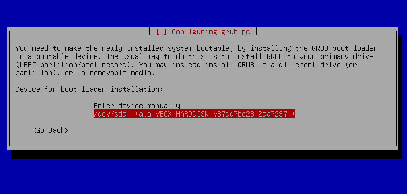

становка системного загрузчика

## Выполнение лабораторной работы

Я завершала установку(рис.24)

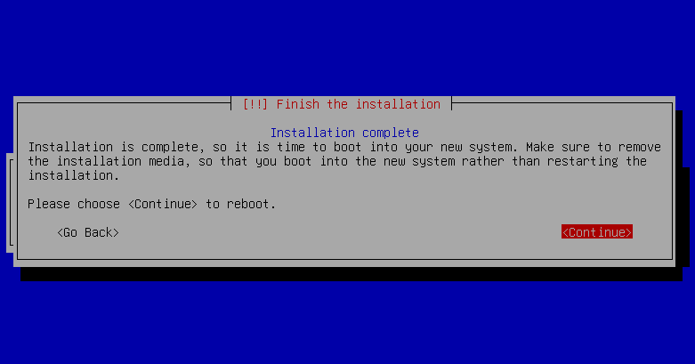

Завершение установки

## Выполнение лабораторной работы

Я проверяла, что в носителях теперь пусто(рис.25)

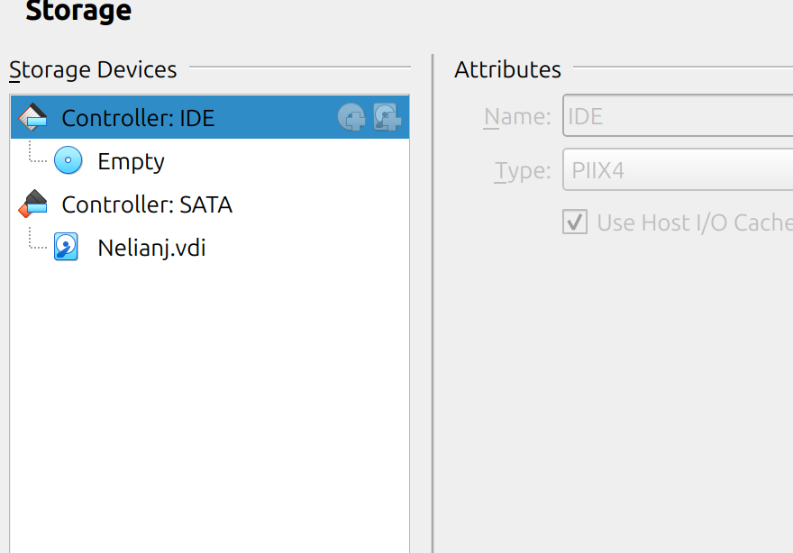

Проверка носителей

## Выполнение лабораторной работы

Я входила в систему от имени своего пользователя(рис.26)

[figure not shown]

вход в систему

## Выполнение лабораторной работы

Это выполнен успешно(рис.27)

[figure not shown]

Успешная загрузка системы

# Выводы

Выполнив эту работу, я приобрела практические навыки по установке операционной системы Linux на витуальную машину.